# Machine Learning

A. M.

Friday, March 20, 2015

**Practical Machine Learning Course Assignment**

The data was collected and made available by Velloso et al. (Qualitative Activity, Recognition of Weight Lifting Exercises, 2013). A training and test set were provided, with data collected from 6 subjects wearing accelerometers at 4 sites on their bodies. The project was motivated to find ways to accurately identify and classify proper and improper technique in terms of a fitness activity, as well as to give potential feedback to a user based on their performance. In this case, each subject was asked to perform a set of 10 repetitions of the Unilateral Dumbbell Biceps Curl, both correctly and in 4 commonly mistaken ways.

The first step is to set up a directory containing the needed files, and then clear the datasets of any unneeded variables.

```r
## Get training set
if (file.exists("./pml-training.csv") == FALSE) {
    download.file("https://d396qusza40orc.cloudfront.net/predmachlearn/pml-training.csv",
                  "pml-training.csv")
}

## Get test set
if (file.exists("./pml-testing.csv") == FALSE) {
    download.file("https://d396qusza40orc.cloudfront.net/predmachlearn/pml-testing.csv",
                  "pml-testing.csv")
}
```

After importing the data, I extracted a relatively small sample to understand the basic characteristics of the datasets.

```r
library(dplyr)

train <- tbl_df(read.csv("pml-training.csv", stringsAsFactors = FALSE))

mysample <- train %>%
    sample_n(2000)

length(names(mysample))
```

```
## [1] 160
```

The current dataframe has 152 variables, excluding identifying markers and the outcome variable. The outcome variable is categorical, with alphabetical levels for each exercise type: A) proper form, B) throwing elbows to the front, C) lifting the dumbbell only halfway, D) Lowering the dumbbell only halfway, E) throwing the hips to the front. The current number of predictors need to be reduced, and potentially non-contributive variables need to be removed.

First, there appear to be computed descriptive statistics (i.e. mean, median, standard-deviation, etc.) for each participant attached to the data frame, leaving thousands of NA values. These will obviously be unhelpful for prediction, and will be excluded. Visual inspection of the variables related to kurtosis, skewness, amplitude, “max”, and “min” also show this characteristic, although they were encoded as character vectors upon import; they will be excluded as well.

```r
library(dplyr)
mysample <- mysample[, !sapply(mysample, function(x) any(is.na(x)))]

mysample <- mysample %>%
    dplyr::select(-contains("kurtosis"), -contains("skewness"),
           -contains("max"), -contains("min"),
           -contains("timestamp"), -contains("window"),
           -contains("amplitude"),
           -user_name) %>%
    dplyr::select(-X)

library(caret)
nzv <- nearZeroVar(mysample, saveMetrics = TRUE)
nzv
```

```
##                      freqRatio percentUnique zeroVar   nzv
## roll_belt             1.207792         20.05   FALSE FALSE
## pitch_belt            1.142857         43.05   FALSE FALSE
## yaw_belt              1.000000         33.60   FALSE FALSE
## total_accel_belt      1.020930          1.25   FALSE FALSE
## gyros_belt_x          1.069444          4.50   FALSE FALSE
## gyros_belt_y          1.141827          2.15   FALSE FALSE
## gyros_belt_z          1.198795          5.50   FALSE FALSE
## accel_belt_x          1.109756          6.60   FALSE FALSE
## accel_belt_y          1.114094          5.25   FALSE FALSE
## accel_belt_z          1.131868          9.95   FALSE FALSE
## magnet_belt_x         1.048780         10.00   FALSE FALSE
## magnet_belt_y         1.148649          9.40   FALSE FALSE
## magnet_belt_z         1.196078         14.10   FALSE FALSE
## roll_arm             32.500000         51.35   FALSE FALSE
## pitch_arm            46.428571         54.60   FALSE FALSE
## yaw_arm              25.000000         54.90   FALSE FALSE
## total_accel_arm       1.139785          2.95   FALSE FALSE
## gyros_arm_x           1.024390         26.05   FALSE FALSE
## gyros_arm_y           1.347826         14.50   FALSE FALSE
## gyros_arm_z           1.477273          8.95   FALSE FALSE
## accel_arm_x           1.052632         28.65   FALSE FALSE
## accel_arm_y           1.227273         21.95   FALSE FALSE
## accel_arm_z           1.214286         27.60   FALSE FALSE
## magnet_arm_x          1.000000         43.70   FALSE FALSE
## magnet_arm_y          1.000000         34.25   FALSE FALSE
## magnet_arm_z          1.166667         41.15   FALSE FALSE
## roll_dumbbell         1.500000         94.35   FALSE FALSE
## pitch_dumbbell        1.619048         92.80   FALSE FALSE
## yaw_dumbbell          1.500000         94.25   FALSE FALSE
## total_accel_dumbbell  1.032680          2.00   FALSE FALSE
## gyros_dumbbell_x      1.092308          8.25   FALSE FALSE
## gyros_dumbbell_y      1.152542         10.00   FALSE FALSE
## gyros_dumbbell_z      1.172414          7.10   FALSE FALSE
## accel_dumbbell_x      1.023810         13.75   FALSE FALSE
## accel_dumbbell_y      1.700000         18.45   FALSE FALSE
## accel_dumbbell_z      1.037037         16.10   FALSE FALSE
## magnet_dumbbell_x     1.333333         30.55   FALSE FALSE
## magnet_dumbbell_y     1.166667         29.85   FALSE FALSE
## magnet_dumbbell_z     1.050000         24.85   FALSE FALSE
## roll_forearm         12.352941         30.70   FALSE FALSE
## pitch_forearm        52.500000         47.80   FALSE FALSE
## yaw_forearm          19.090909         32.50   FALSE FALSE
## total_accel_forearm   1.088000          2.95   FALSE FALSE
## gyros_forearm_x       1.295455         10.30   FALSE FALSE
## gyros_forearm_y       1.050000         27.10   FALSE FALSE
## gyros_forearm_z       1.309524         10.40   FALSE FALSE
## accel_forearm_x       1.400000         32.55   FALSE FALSE
## accel_forearm_y       1.153846         36.80   FALSE FALSE
## accel_forearm_z       1.411765         21.50   FALSE FALSE
## magnet_forearm_x      1.166667         42.85   FALSE FALSE
## magnet_forearm_y      1.090909         49.05   FALSE FALSE
## magnet_forearm_z      1.000000         46.50   FALSE FALSE
## classe                1.326087          0.25   FALSE FALSE
```

Excluding these variables leaves 52 predictors, all of them showing acceptable levels of variance. All predictors were reassigned as numeric values for analysis, and the outcome variable was reassigned as a factor.

```r
## remove extraneous variables
train <- train <- train[, !sapply(train, function(x) any(is.na(x)))]
train <- train %>%
    dplyr::select(-contains("kurtosis"), -contains("skewness"),
           -contains("max"), -contains("min"),
           -contains("timestamp"), -contains("window"),
           -contains("amplitude"),
           -user_name) %>%
    dplyr::select(-X)

## reclassify predictors as numeric vars, set outcome as factor var
train[, 1:52] <- sapply(train[, 1:52], as.numeric)
train[, 53] <- factor(train$classe)

## create partition for further validation
library(caret)
inQuiz <- createDataPartition(train$classe, p = .4, list = FALSE)

## define training and quiz set
newTrain <- train[-inQuiz,]
newQuiz <- train[inQuiz,]
```

```r
## model 1, LDA with 5 folds, 10 reps
fitControl <- trainControl(method = "repeatedcv", number = 5, repeats = 10)
ldafit <- train(classe ~ ., data = newTrain, method = "lda", trControl = fitControl)
## random-forests with 3 folds, 10 reps -- 500 trees
fitControl <- trainControl(method = "repeatedcv", number = 3, repeats = 10)
system.time(rffit <- train(classe ~ ., data = newTrain, method = "rf", ntree = 500, trainControl = fitControl))
```

```
##    user  system elapsed
## 2283.32   10.86 2295.78
```

Having built both models, their predictive power was tested on the quiz set.

```r
ldapred <- predict.train(ldafit, newQuiz, type = "raw")
## LDA-based model
confusionMatrix(ldapred, newQuiz$classe)
```

```
## Confusion Matrix and Statistics
##
##           Reference
## Prediction    A    B    C    D    E
##          A 1846  246  138   93   55
##          B   46  943  163   52  249
##          C  161  180  886  149  134
##          D  171   65  151  942  166
##          E    8   85   31   51  839
##
## Overall Statistics
##
##                Accuracy : 0.695
##                  95% CI : (0.6847, 0.7052)
##     No Information Rate : 0.2843
##     P-Value [Acc > NIR] : < 2.2e-16
##
##                   Kappa : 0.6137
##  Mcnemar's Test P-Value : < 2.2e-16
##
## Statistics by Class:
##
##                      Class: A Class: B Class: C Class: D Class: E
## Sensitivity            0.8271   0.6208   0.6472   0.7319   0.5814
## Specificity            0.9053   0.9194   0.9037   0.9157   0.9727
## Pos Pred Value         0.7763   0.6490   0.5868   0.6301   0.8274
## Neg Pred Value         0.9295   0.9100   0.9238   0.9457   0.9116
## Prevalence             0.2843   0.1935   0.1744   0.1639   0.1838
## Detection Rate         0.2352   0.1201   0.1129   0.1200   0.1069
## Detection Prevalence   0.3029   0.1851   0.1924   0.1904   0.1292
## Balanced Accuracy      0.8662   0.7701   0.7755   0.8238   0.7771
```

```r
varImp(rffit)
```

```
## rf variable importance
##
##   only 20 most important variables shown (out of 52)
##
##                   Overall
## roll_belt          100.00
## yaw_belt            77.82
## magnet_dumbbell_z   67.43
## magnet_dumbbell_y   62.14
## pitch_forearm       61.77
## pitch_belt          61.49
## magnet_dumbbell_x   52.09
## roll_forearm        48.63
## accel_belt_z        45.09
## magnet_belt_y       43.76
## roll_dumbbell       43.65
## magnet_belt_z       41.86
## accel_dumbbell_y    41.80
## accel_dumbbell_z    37.16
## accel_forearm_x     33.65
## roll_arm            31.36
## accel_dumbbell_x    29.63
## yaw_dumbbell        28.69
## gyros_belt_z        27.53
## magnet_forearm_z    27.40
```

```r
rfpred <- predict.train(rffit, newQuiz, type = "raw")
## Random-forests based model
confusionMatrix(rfpred, newQuiz$classe)
```

```
## Confusion Matrix and Statistics
##
##           Reference
## Prediction    A    B    C    D    E
##          A 2232    8    0    0    0
##          B    0 1501   11    0    0
##          C    0   10 1358   20    1
##          D    0    0    0 1266   13
##          E    0    0    0    1 1429
##
## Overall Statistics
##
##                Accuracy : 0.9918
##                  95% CI : (0.9896, 0.9937)
##     No Information Rate : 0.2843
##     P-Value [Acc > NIR] : < 2.2e-16
##
##                   Kappa : 0.9897
##  Mcnemar's Test P-Value : NA
##
## Statistics by Class:
##
##                      Class: A Class: B Class: C Class: D Class: E
## Sensitivity            1.0000   0.9882   0.9920   0.9837   0.9903
## Specificity            0.9986   0.9983   0.9952   0.9980   0.9998
## Pos Pred Value         0.9964   0.9927   0.9777   0.9898   0.9993
## Neg Pred Value         1.0000   0.9972   0.9983   0.9968   0.9978
## Prevalence             0.2843   0.1935   0.1744   0.1639   0.1838
## Detection Rate         0.2843   0.1912   0.1730   0.1613   0.1820
## Detection Prevalence   0.2854   0.1926   0.1769   0.1629   0.1822
## Balanced Accuracy      0.9993   0.9932   0.9936   0.9909   0.9951
```

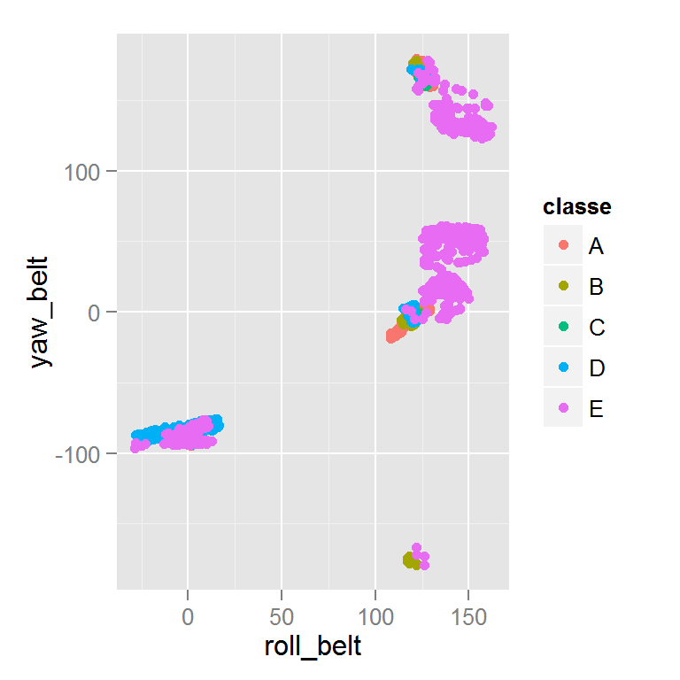

```r
ggplot(newQuiz, aes(roll_belt, yaw_belt, color = classe)) + geom_point()
```

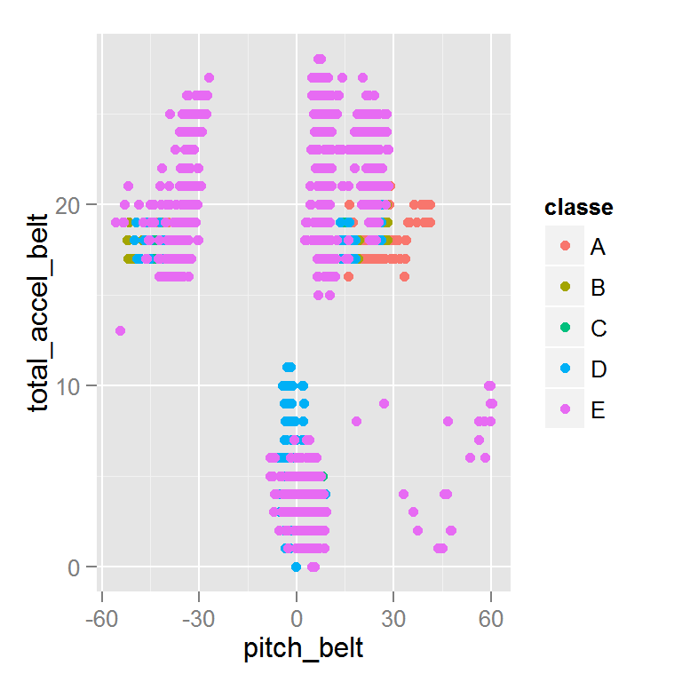

```r
ggplot(newQuiz, aes(pitch_belt, total_accel_belt, color = classe)) + geom_point()
```

Exercises where the subjects were asked to engage their hips are (as one would expect) highly related to the belt-accelerometer. However, variables related to this accelerometer also confirm their importance graphically. While there appears to be much higher variability in plotting motion related to the arm-mounted accelerometers, there appear to be relatively distinct patterns of motion that can be detected by the belt accelerometer alone. This presents an exciting possibility of reducing the number of sensors needed to track/classify exercise-related movement, which prevents high levels of convenience for individuals interested in tracking their performance.

Having built the models, the next step is to import, clean, and predict the test data with our fitted model.

```r
test <- tbl_df(read.csv("pml-testing.csv", stringsAsFactors = TRUE))

test <- test <- test[, !sapply(test, function(x) any(is.na(x)))]
test <- test %>%
    dplyr::select(-contains("kurtosis"), -contains("skewness"),
           -contains("max"), -contains("min"),
           -contains("timestamp"), -contains("window"),
           -contains("amplitude"),
           -user_name) %>%
    dplyr::select(-X)

test[, 1:52] <- sapply(test[, 1:52], as.numeric)
test[, 53] <- factor(test$classe)

finalldapred <- predict.train(ldafit, test, type = "raw")

finalrfpred <- predict.train(rffit, test, type = "raw")
```